# Week 3 Exercise — Unsupervised Learning: PCA & Clustering

PubH 6010 Independent Study · meeting 9/9 · complete after the meeting

Your name: Katie O’Brien

2026-09-15

# 1 Why this matters for your project

Your project asks whether extreme-weather events change waterborne-disease risk. Real environmental-health data almost always come as **many correlated exposure variables measured on the same people or places** — a dozen water-chemistry parameters, a panel of contaminants, a set of weather indices. Two problems follow: the variables are redundant (highly correlated), and you often have no labels telling you which observations “go together.” **Unsupervised learning** addresses both:

- **Principal Component Analysis (PCA)** compresses many correlated variables into a few uncorrelated components that capture most of the variation — useful for visualization, for summarizing an exposure “mixture,” and as a dimension-reduction step before modeling.
- **Clustering** (k-means, hierarchical) groups observations into profiles without using an outcome — useful for finding exposure subpopulations.

A caution to carry the whole way through: **PCA and clustering are descriptive, not causal, and not prediction of an outcome.** They use only the exposure matrix `X`; no outcome `Y` enters. Keep that straight — it is exactly the prediction-vs-description-vs-causation distinction that will shape your dissertation’s method choice.

# 2 The paper to read first

> Gibson EA, Nunez Y, Abuawad A, Zota AR, Renzetti S, Devick KL, Gennings C, Goldsmith J, Coull BA, Kioumourtzoglou M-A. **An overview of methods to address distinct research questions on environmental mixtures: an application to persistent organic pollutants and leukocyte telomere length.** *Environmental Health.* 2019;18:76. doi:10.1186/s12940-019-0515-1 (open access)

Read the **Introduction** and the **PCA** and **clustering/profile** subsections. As you read, note: (1) what question each unsupervised method is answering, and (2) how the authors decide *how many* components or clusters to keep. You will reproduce a simplified version of their PCA and clustering on the same data.

# 3 The data

`studypop.csv` — NHANES 2001–2002, 1,330 US adults. It contains **18 lipid-adjusted persistent organic pollutants (POPs)** — 11 PCBs, 3 dioxins, 4 furans — plus leukocyte telomere length (`TELOMEAN`) and covariates. See `studypop_data_dictionary.Rmd` for every column. These POPs are highly correlated (they share sources and all accumulate in body fat), which is precisely why PCA and clustering are informative here. The data are public and deidentified.

# 4 Your tasks

Work in R. You need only base R plus the `cluster` package (which installs with R). Submit your knitted `.Rmd` (or a commented `.R` script) and a short write-up (≈1–2 pages) answering the questions in **bold**.

## 4.1 Part A — Set up and preprocess

1. Read the data. Keep the 18 POP columns and drop rows with any missing POP value (`complete.cases`). Report how many participants remain.
2. POP concentrations are strongly right-skewed and on different scales. **Log-transform** them, then **standardize** (`scale()`).

```r
library(cluster)
set.seed(2026)
d <- read.csv("studypop.csv")
pops <- c("LBX074LA","LBX099LA","LBX118LA","LBX138LA","LBX153LA","LBX170LA",
          "LBX180LA","LBX187LA","LBX194LA","LBXPCBLA","LBXHXCLA",
          "LBXD03LA","LBXD05LA","LBXD07LA","LBXF03LA","LBXF04LA","LBXF05LA","LBXF08LA")
X  <- d[complete.cases(d[, pops]), pops]
Xs <- scale(log(X))

# there are 1,007 participants remaining
```

> **Q1.** Why is standardizing essential before PCA and before distance-based clustering? What would happen if you skipped it?

Standardizing is essential because the units of variables differ. Having different units results in different ranges. If standardizing was not done, variables with larger variances would disproportionately inform the solution.

## 4.2 Part B — PCA

3. Run PCA (`prcomp`) on the standardized POPs. Make a **scree plot** and report the proportion of variance explained by the first several components.

```r
# PCA
pc <- prcomp(Xs)
summary(pc)
```

```
## Importance of components:
##                           PC1    PC2     PC3     PC4     PC5     PC6    PC7
## Standard deviation     3.3795 1.3893 1.02492 0.84099 0.77245 0.67595 0.5985
## Proportion of Variance 0.6345 0.1072 0.05836 0.03929 0.03315 0.02538 0.0199
## Cumulative Proportion  0.6345 0.7417 0.80008 0.83938 0.87253 0.89791 0.9178
##                            PC8    PC9    PC10    PC11    PC12    PC13    PC14
## Standard deviation     0.57100 0.4800 0.44014 0.42544 0.41449 0.38161 0.26923
## Proportion of Variance 0.01811 0.0128 0.01076 0.01006 0.00954 0.00809 0.00403
## Cumulative Proportion  0.93592 0.9487 0.95949 0.96954 0.97909 0.98718 0.99120
##                           PC15    PC16    PC17    PC18
## Standard deviation     0.25881 0.21111 0.17832 0.12234
## Proportion of Variance 0.00372 0.00248 0.00177 0.00083
## Cumulative Proportion  0.99493 0.99740 0.99917 1.00000
```

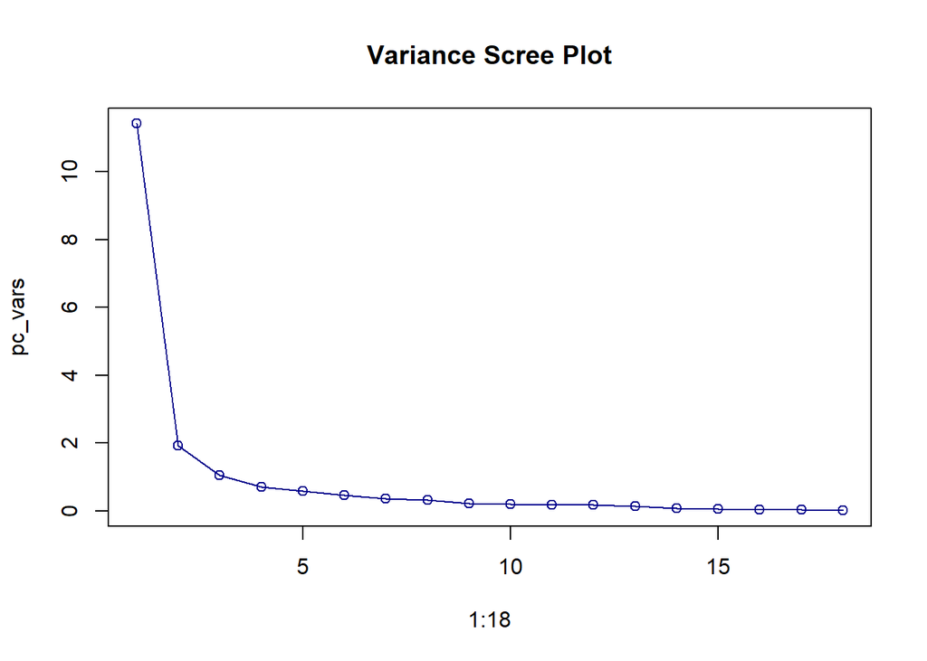

```r
# PC1 explains 63.45% of the variance, PC2 explains 10.72% of the variance, and PC3 explains 5.84% of the variance.

# variance scree plot
pc_vars <- pc$sdev^2
plot(1:18, pc_vars, type = "l", col = "blue4", main = "Variance Scree Plot")
points(1:18, pc_vars, col = "blue4")
```

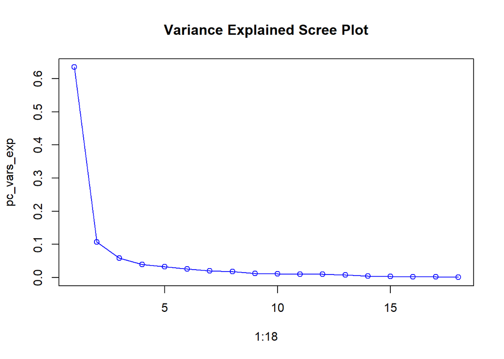

```r
# variance explained scree plot
pc_vars_exp <- pc$sdev^2 / sum(pc$sdev^2)
plot(1:18, pc_vars_exp, type = "l", col = "blue", main = "Variance Explained Scree Plot")
points(1:18, pc_vars_exp, col = "blue")
```

> **Q2.** How many components would you keep, and by what rule? (Compare at least two rules — e.g., cumulative-variance threshold vs. the scree “elbow.”)

I would keep the first three principle components. Based on the scree plot, the “elbow” is situated around PC2-PC3. Additionally, the first three principle components explain 80% of the cumulative variance. While there is no defined threshold, >75% of the total variance is what was used in the original paper.

4. Examine the **loadings** of PC1 and PC2 (`pc$rotation[, 1:2]`).

```r
pc$rotation[, 1:2]
```

```
##                 PC1         PC2
## LBX074LA -0.2550421 -0.08699047
## LBX099LA -0.2477299 -0.09431688
## LBX118LA -0.2564446 -0.03464868
## LBX138LA -0.2741345 -0.15506911
## LBX153LA -0.2767193 -0.18407340
## LBX170LA -0.2710364 -0.21632120
## LBX180LA -0.2654395 -0.21453582
## LBX187LA -0.2656881 -0.18864124
## LBX194LA -0.2460723 -0.23163529
## LBXPCBLA -0.1874510  0.14949152
## LBXHXCLA -0.2532277 -0.10679129
## LBXD03LA -0.2349829  0.14731417
## LBXD05LA -0.1660988  0.44701803
## LBXD07LA -0.1904922  0.38090837
## LBXF03LA -0.2226564  0.07131114
## LBXF04LA -0.2277594  0.29140363
## LBXF05LA -0.2206952  0.26323046
## LBXF08LA -0.1119105  0.42741620
```

> **Q3.** Give each of PC1 and PC2 a substantive name based on which POPs load on it. What does a person with a high PC1 score look like? A high PC2 score?

5. Make a **biplot** of PC1 vs PC2.

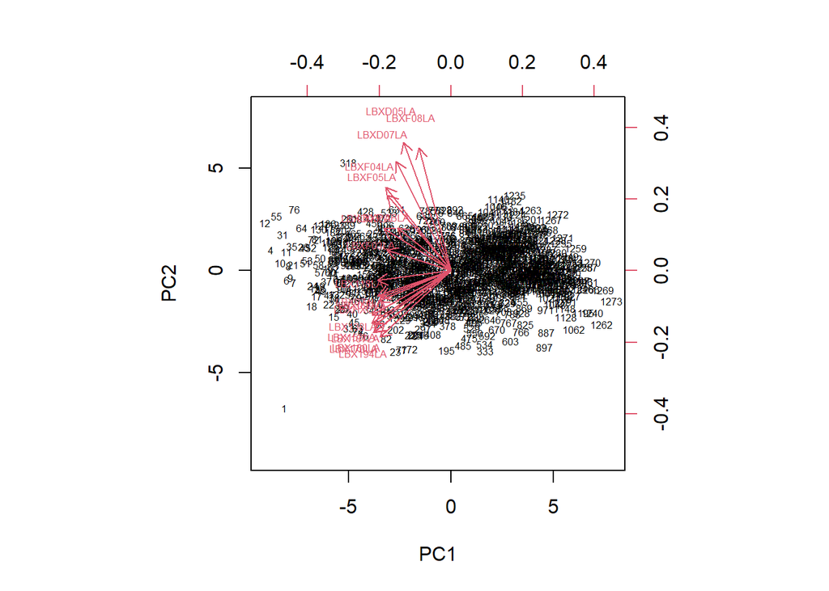

```r
biplot(pc, cex = 0.5, scale = 0)
```

> **Q4.** What structure among the 18 POPs does the biplot reveal?

The bioplot reveals that the non-dioxin like PCBs are more closely related compared to the other POPs. This is evidenced by the small angles between the arrows for these POPs.

## 4.3 Part C — Clustering

6. Cluster participants into exposure profiles two ways:
   - **k-means** on the first 2–3 PC scores. Use the **average silhouette width** (`cluster::silhouette`) to compare k = 2…6, then pick a k and describe the clusters.
   - **Hierarchical clustering** (`hclust`, Ward’s method) on the standardized POPs. Plot the **dendrogram**, cut it into the same number of groups (`cutree`), and cross-tabulate against the k-means labels.

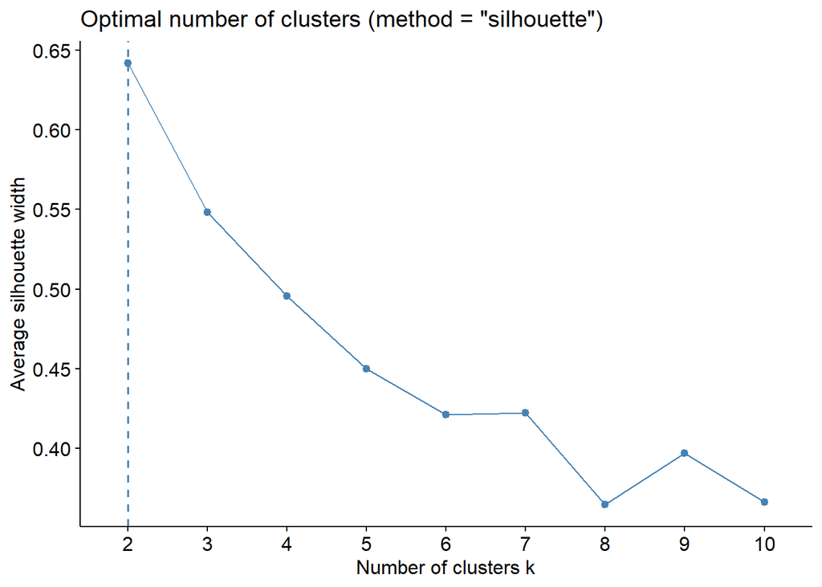

```r
# k-means clustering

# using silhouette to find optimal number of clusters
avg_sil <- function(k){
  km <- kmeans(pc$x, centers = k, nstart = 25)
  sil <- silhouette(km$cluster, dist(X))
  mean(sil[, 3])
}
k_vals <- 2:6
avg_sil_vals <- sapply(k_vals, avg_sil)
# k = 2 has the highest value

# another way to use silhouette to find optimal number of clusters
library(factoextra)
fviz_nbclust(X, kmeans, method = "silhouette")
```

```r
km_2 <- kmeans(pc$x[, 1:3], centers = 2, nstart = 25)
print(km_2)
```

```
## K-means clustering with 2 clusters of sizes 532, 475
##
## Cluster means:
##         PC1         PC2         PC3
## 1  2.677278  0.09687144 -0.01503199
## 2 -2.998551 -0.10849601  0.01683583
##
## Clustering vector:
##    1    4    6    7    8    9   10   11   12   13   14   15   16   17   18   19
##    2    2    2    2    2    2    2    2    2    2    2    2    2    2    2    2
##   20   21   22   23   24   25   26   28   31   32   33   34   35   37   38   39
##    2    2    2    2    2    2    2    2    2    2    2    2    2    2    2    2
##   40   42   43   44   45   46   47   49   50   51   52   53   55   57   58   60
##    2    2    2    2    2    2    2    2    2    2    2    2    2    2    2    2
##   61   62   63   64   65   66   67   70   72   73   74   75   76   77   79   81
```

[output cut: 128 more lines]

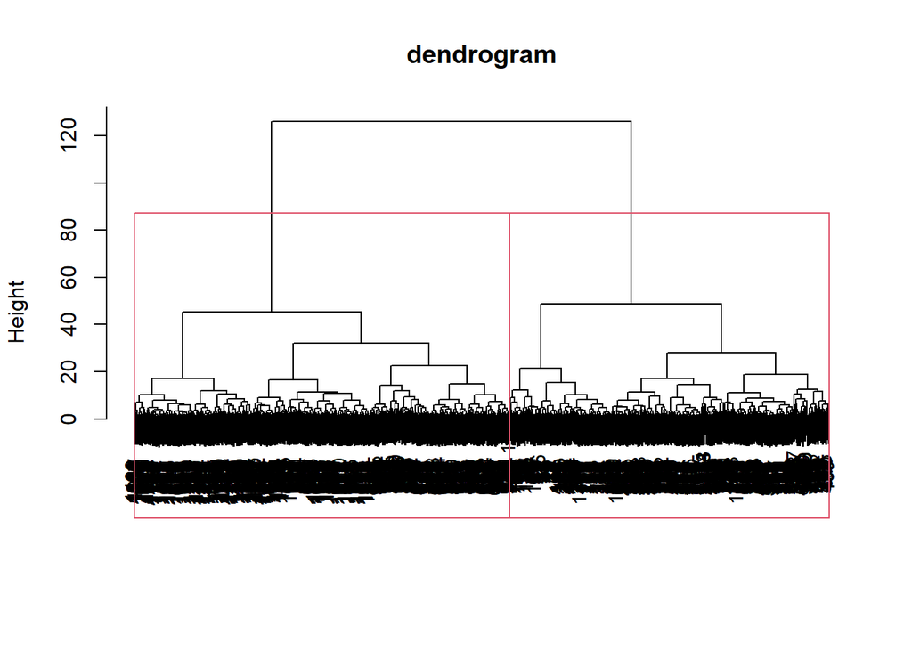

```r
# hierarchial clustering
hc <- hclust(dist(Xs), method = "ward.D2")
plot(hc, main = "dendrogram", xlab = "", sub = "", cex = 0.9)
rect.hclust(hc, k = 2)
```

```r
# cutree(hc, k = 2)
```

> **Q5.** How many clusters does the silhouette analysis favor? Do k-means and hierarchical clustering broadly agree? Describe each cluster in plain language (e.g., “low overall burden,” “high, PCB-dominated”).

## 4.4 Part D — Interpretation

> **Q6.** You did not use telomere length anywhere in Parts B–C. Explain why PCA and clustering are *descriptive/unsupervised*. For your own project, name one concrete way PCA or clustering could be a useful *step* — and one thing they cannot tell you.

For my project, PCA could be useful in identifying which factors are most influential in WBD disease transmission following flooding (e.g. increased pathogens in the environment, disruptions in water treatment), should data on this exist. Clustering may be helpful in identifying subgroups susceptible to increased WBDs rates following flooding. However, neither PCA or clustering would be able to speak to any causal links, as they are meant only for hypothesis generation or descriptive analyses.

# 5 Starter code (fill in the blanks)

```r
library(cluster)
set.seed(2026)
d <- read.csv("studypop.csv")
pops <- c("LBX074LA","LBX099LA","LBX118LA","LBX138LA","LBX153LA","LBX170LA",
          "LBX180LA","LBX187LA","LBX194LA","LBXPCBLA","LBXHXCLA",
          "LBXD03LA","LBXD05LA","LBXD07LA","LBXF03LA","LBXF04LA","LBXF05LA","LBXF08LA")
X  <- d[complete.cases(d[, pops]), pops]
Xs <- scale(log(X))            # log, then standardize
pc <- prcomp(Xs)               # PCA  -> summary(pc), pc$rotation, pc$x
# ... scree plot, loadings, biplot ...
# km <- kmeans(pc$x[, 1:3], centers = ?, nstart = 25)   # k-means
# hc <- hclust(dist(Xs), method = "ward.D2")            # hierarchical
```

# 6 What “good” looks like

A correct submission (i) preprocesses sensibly and justifies it, (ii) keeps a defensible number of components with a stated rule, (iii) interprets PC1/PC2 substantively, (iv) chooses k with the silhouette and describes the clusters, and (v) in Q6 draws a clean line between description, prediction, and causation. Numerical answers should land near: ~1,000 complete cases; PC1 ≈ 60–65% of variance; PC1 an “overall burden” axis; PC2 a “PCB vs dioxin/furan” contrast.